# Working with raster data - Tuesday pm

C. A. Hamm

June 21, 2016

## Objetives

Start by putting up objectives/tasks that students will be working though:

1. Import a raster — A lidar canopy height model (lidar/Teak_lidarCHM.tif)
2. For the CHM, set values == 0 to NA (not trees) Classify the raster according to some distribution – low medium and tall trees. This could be done using a histogram potentially or we could just decide that <2m is generally grasses / understory, <6m small trees,and the rest are tall trees. A function could import the desired thresholds. Visualize histogram/density and plot vertical cutoff lines.
3. PLOT - layer the classified raster, add a legend for each “class” - legends are super tricky to simplifying this process with a function would be good. see: http://neon-workwithdata.github.io/neon-data-institute-2016/R/classify-by-threshold-R/ for my take on forcing a legend outside of the plot area using par settings. You may have other better forms of magic to make this work well. :)
4. Export the plot figure to a pdf – publishable
5. Export the classified raster as a geotiff with NaFlag = -9999 to an outputs folder.

```r
set.seed(9862144)
setwd("~/Desktop/Projects/NEON-2016/NEONDI-2016/Tuesday_pm/")
library("raster")
library("rgdal")
library("neonAOP")

sink(paste0(format(Sys.time(), "%Y-%m-%d_%H%M%S"), "_sessionInfo.txt"))
```

```r
sink()
```

### Objective #1

```r
# set path to file
TEAK_file <- "../NEONdata/D17-California/TEAK/2013/lidar/TEAK_lidarCHM.tif"
# import the file using the raster() function
tchm <- raster(TEAK_file)
```

### Objective #2

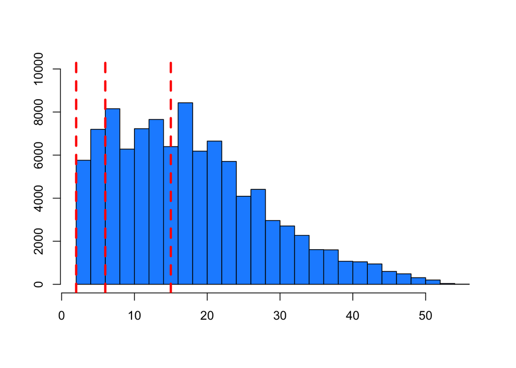

```r
# set the 0 values to NA
tchm[tchm == 0] <- NA
# classify data based on some criterion
hist(tchm, col = "dodgerblue", breaks = 20, ylim = c(0, 1e4), ylab = "", xlab = "", main = "")
abline(v = c(2, 6, 15), lwd = 3, lty = 2, col = "red")
```

```r
# will establish break ranges and convert to matrix
brackets <- matrix(c(0, 6, 1,
            6, 10, 2,
            10, 20, 3,
            20, 70, 4),
            ncol = 3, byrow = TRUE)
brackets
```

```
##      [,1] [,2] [,3]
## [1,]    0    6    1
## [2,]    6   10    2
## [3,]   10   20    3
## [4,]   20   70    4
```

```r
re_tchm <- reclassify(tchm, brackets)
```

### Objective #3 & #4

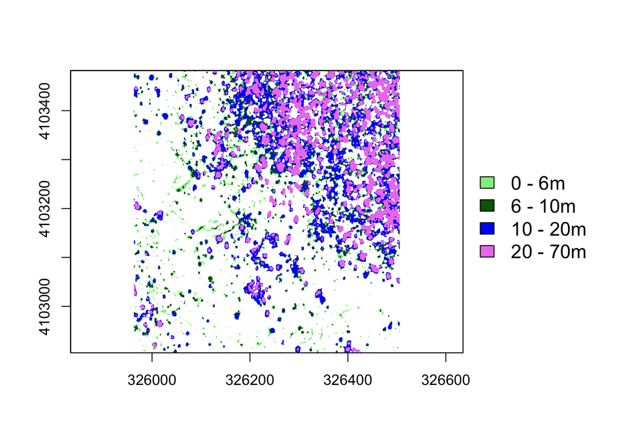

```r
# plot the figure
par(xpd = FALSE, mar = c(5, 4, 4, 6))
plot(re_tchm, col = c("light green", "dark green", "blue", "violet"), legend = FALSE)
par(xpd = TRUE)
legend(par()$usr[2], 4103300, legend = c("0 - 6m", "6 - 10m", "10 - 20m", "20 - 70m"), fill = c("light green", "dark green", "blue", "violet"), bty = "n", cex = 1.3)
```

```r
# send the figure to a .pdf
pdf(file = "../outputs/TEAK/Teak_CHM_classified.pdf", bg = "white")
par(xpd = FALSE, mar = c(5, 4, 4, 6))
plot(re_tchm, col = c("light green", "dark green", "blue", "violet"), legend = FALSE)
par(xpd = TRUE)
legend(par()$usr[2], 4103300, legend = c("0 - 6m", "6 - 10m", "10 - 20m", "20 - 70m"), fill = c("light green", "dark green", "blue", "violet"), bty = "n", cex = 1.3)
dev.off()
```

### Objective #5

```r
writeRaster(re_tchm, filename = "../outputs/TEAK/Teak_CHM_classified.tif", format = "GTiff", options = "COMPRESS = LZW", overwrite = TRUE, NAflag = -9999)
```